# Analysis of WHO Ebola data

Sangeeta Bhatia

Imperial College London

# Data clean-up

The current data set has three possible values for the epidemiological case definition - confirmed, probable and suspected. Epidemiological case definition of probable and suspected cases differed across countries while confirmed cases were the ones confirmed through lab report. For the purpose of the current analysis, one approach could be to lump all of them together. The inferred date of onset (rather than the date reported) is used for estimation. The columns we use are : Country, EpiCaseDef (probably), DateOnsetInferred and CL_DistrictRes.

## Grouping by districts and interpolating missing data

For each district in a country, add the number of records for each date to get incidence count.

Within each district, if there is a date on which no cases are recorded, we assume that there were no cases on that date and add this to the record. At the end of this step, the incidence time series for each district should be a daily time series.

Read in data prepared using the above code chunks.

# Parameters for Ebola

Culled from literature.

# Comparison with the data from Health Map and ProMed

First read in and clean up the data from Health Map. Since these data are at national level, we will also aggregate the WHO data at country level. HealthMap collects and curates data on the cumulative number of cases (C) and deaths (D) stratified by status (suspected, SC/SD, or confirmed CC/CD). For data from the WHO, the case status could be confirmed, probable or suspected. The final clinical outcome (alive/dead) for each case is also recorded. In comparing the two data sets, we sum across all four categories in Healthmap and derive incidence data from cumulative data.

ProMed data is similarly stratfied and we will sum across the catgories of suspected and confirmed cases for ProMed.

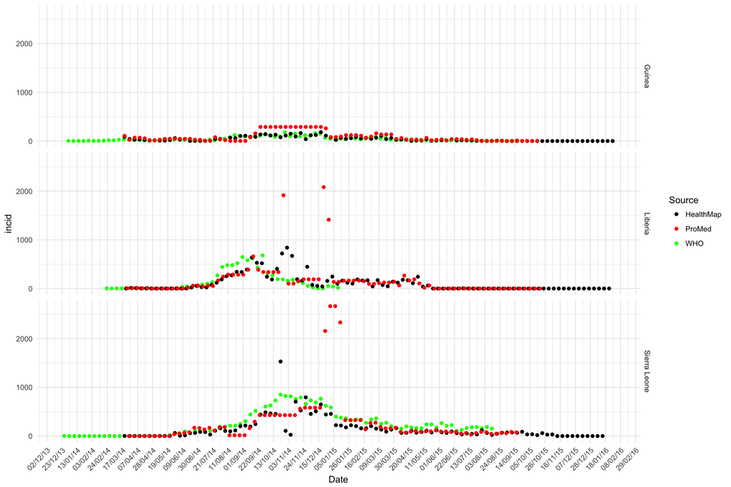

## Estimating Reproduction number from WHO and Healthmap Data

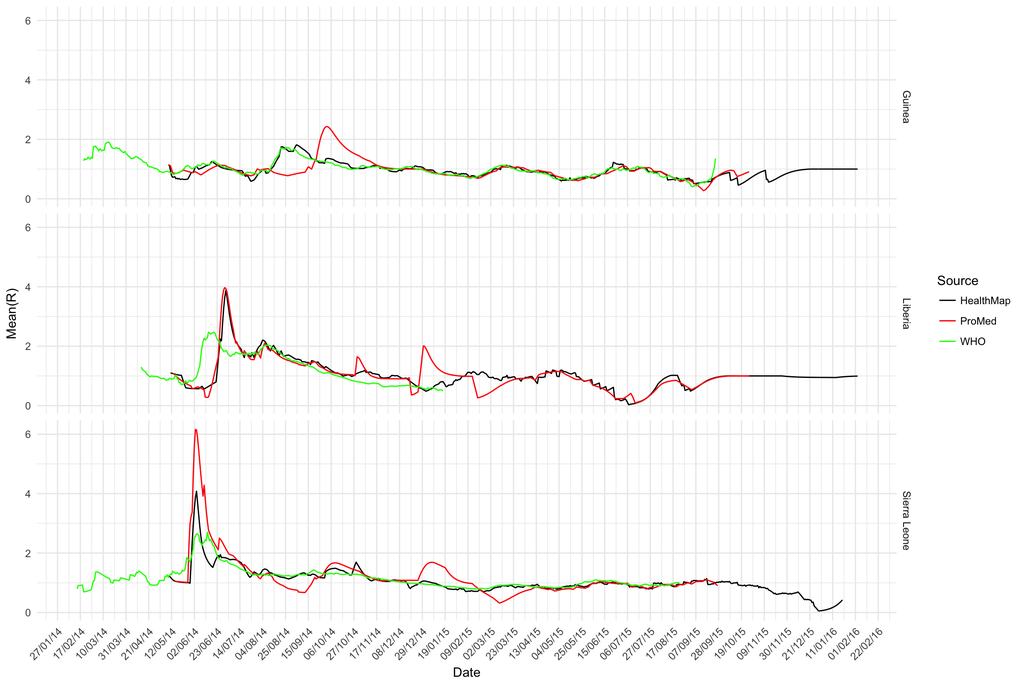

The graphs show that the estimates from the three different sources closely track each other. Here’s another way to visualise this.

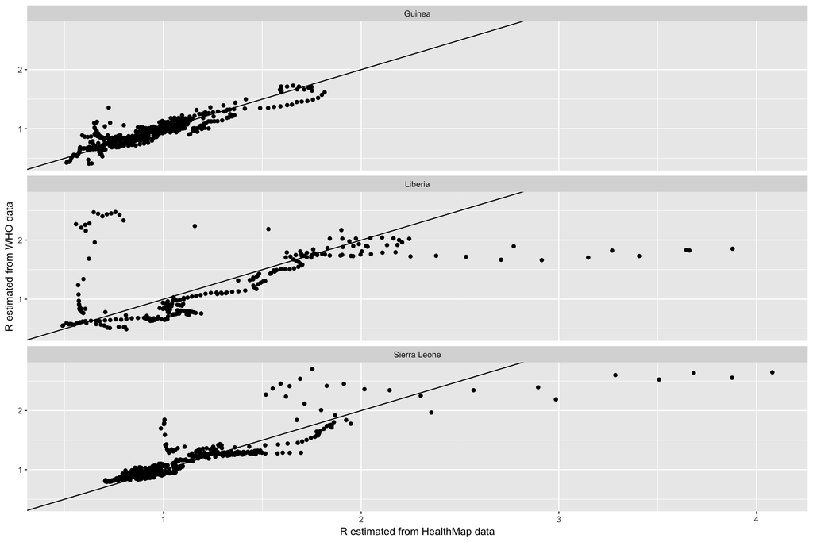

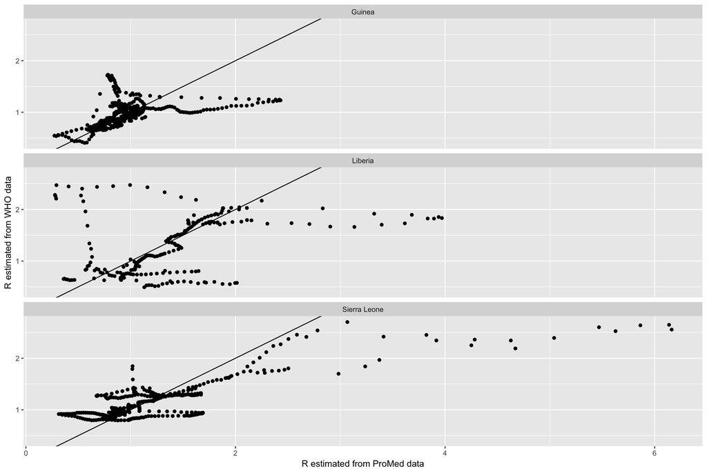

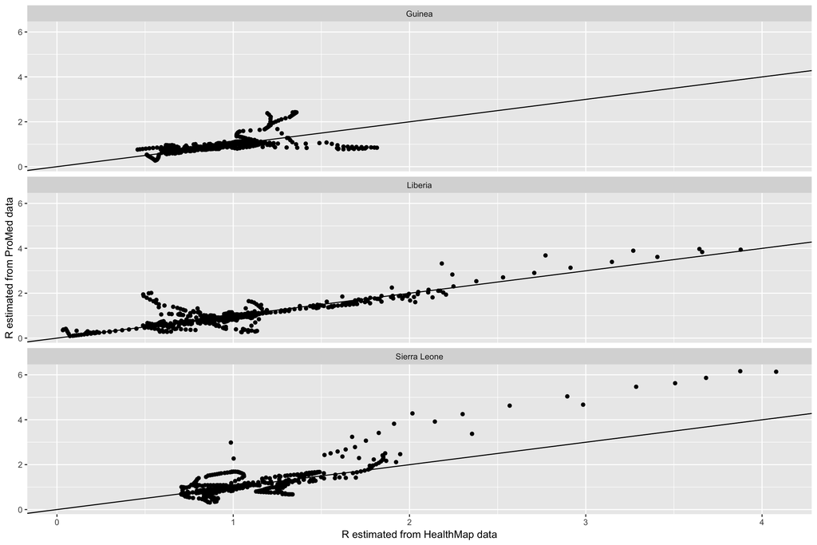

```
##              ProMed       WHO HealthMap
## ProMed    1.0000000 0.6323368 0.8068321
## WHO       0.6323368 1.0000000 0.7601866
## HealthMap 0.8068321 0.7601866 1.0000000
```

# Projection using WHO data

## Projection within Sierra Leone

## Projection within Liberia

## Projection across all districts within Sierra Leone, Liberia and Guinea

## Evaluating goodness of fit